# Binary classification with bitmodeling

Choonghyun Ryu

2023-02-18

## 개요

tidymodels 프레임워크를 이용한 binary classification vignette를 통해서 레시피와 워크플오우의 개념을 충분히 이해하였을 것이라 생각합니다. 그리고 이런 데이터 분석 어프러치의 장점도 공감했을 것이라 기대합니다.

그러나 tidymodels 프레임워크 초심자나 좀더 자동화 루틴화된 방법을 원하는 분석가를 위해서 bitmodeling 패키지에서 구현한 tidymodels 프레임워크 래핑 기반의 분석 방법을 소개합니다.

이 소개에서는 다음과 같은 방법을 다룹니다.

- 손쉬운 레시피 정의하기
- 대표적인 binary classifiers의 모델링
- 여러 binary classifiers를 적용한 모델링
- 복수개의 레시피에 여러 binary classifiers를 적용한 모델링
- 모델링 결과에 대한 성능평가
- 모델링 결과에 대한 성능평가 보고서 자동 생성

## 손쉬운 레시피 정의하기

파이프라인 처리 방법으로 레시피를 정의하는 방법을 다룹니다. tidymodels 프레임워크 방법보다 더 논리적입니다.

binary classification 모델링을 수행했던 기존의 방법과 의사결정 체계를 이미지화하면, 이 방법에 좀 더 쉽게 적응할 수 있을 겁니다.

### 데이터 소개

`dlookr::heartfailure`는 심혈관 질환의 하나인 심부전으로 인한 사망을 예측하는데 사용할 수 있는 심부전 환자의 데이터셋입니다. 299건의 관측치와 다음과 같은 13개의 변수로 구성되어 있습니다.

- age
  - 환자의 나이
- anaemia
  - 변혈 여부. 적혈구 또는 헤모글로빈 감소
  - Yes/No
- cpk_enzyme
  - 혈중 CPK(creatinine phosphokinase) 효소의 수치 (mcg/L).
- diabetes
  - 당뇨병 여부
  - Yes/No
- ejection_fraction
  - 수축치 심장에서 나가는 혈액의 비율 (백분율)
- hblood_pressure
  - 고혈압 여부
  - Yes/No
- platelets
  - 혈액내 혈소판 수 (1,000/mL).
- creatinine
  - 혈중 크레아티닌 수치 (mg/dL).
- sodium
  - 혈중 나트륨 수치 (mEq/L).
- sex
  - 환자의 성별
  - Male/Female
- smoking
  - 흡연 여부
  - Yes/No
- time
  - 후속 조치 기간 (일)
- death_event
  - 추적 기간동안의 환자의 사망여부
  - Yes/No

tidymodels 패키지를 이용해서, `dlookr::heartfailure`로 심부전 환자에 대한 사망 여부를 예측하는 Binary Classification 모델을 개발할 것입니다.

### target 변수 선정하기

자, binary classification 모델링을 위한 데이터셋이 주어졌습니다. 우리는 제일 먼저 target 변수를 정의합니다.

`target_to()` 함수로 데이터셋에서 타겟 변수를 선택하기만 하면 됩니다.

```r
library(bitmodeling)

data_recipe <- dlookr::heartfailure %>%
  target_to(death_event)
```

### positive 클래스 정의하기

우리는 무엇을 예측할 것인가요? 관심있는 클래스인 positive 클래스를 선택해야 되죠.

`set_positive()` 함수로 앞에서 정의한 target 변수의 positive 클래스를 선택합니다.

```r
data_recipe <- dlookr::heartfailure %>%
  target_to(death_event) %>%
  set_positive("Yes")
```

### 데이터셋 분리비율 정하기

이제는 본격적으로 모델링에 들어가기 위해서 훈련 데이터 셋과 평가 데이터 셋을 정의합니다.

`split_dataset()` 함수로 7:3의 비율로 분리하는 레시피를 만듭니다. 이렇게 계속 추가해 나가는 거죠.

```r
data_recipe <- dlookr::heartfailure %>%
  target_to(death_event) %>%
  set_positive("Yes") %>%
  split_dataset(prop = 0.7)
```

### 데이터셋 추출하기

7:3의 비율로 분리하는 레시피에서 훈련 데이터셋을 추출합니다.

`extract_dataset()` 함수로 훈련 데이터 셋을 추출합니다. 물론 평가 데이터 셋의 추출도 가능합니다.

```r
data_recipe <- dlookr::heartfailure %>%
  target_to(death_event) %>%
  set_positive("Yes") %>%
  split_dataset(prop = 0.7) %>%
  extract_dataset()
```

### target 변수의 불균형도 살펴보기

`target_table()` 함수로 추출한 훈련 데이터 셋에서의 target 변수의 두 클래스의 비율을 살펴봅니다.

positive 클래스인 `Yes`가 minority 클래스이군요. 불균형을 해소하는 레시피를 만들어야 겠다고 잠깐 찜해둡니다.

```r
data_recipe %>%
  target_table()
ℹ Training 데이터의 Target 변수 분포
# A tibble: 2 × 3
  death_event  건수 백분율
  <fct>       <int>  <dbl>
1 No            142   67.9
2 Yes            67   32.1
```

`target_table()` 함수는 꼭 데이터를 추출한 후에만 사용할 수 있을까요? 그렇지 않습니다.

target 변수를 선정 후에도 가능합니다.

```r
dlookr::heartfailure %>%
  target_to(death_event) %>%
  target_table()
ℹ 원 데이터의 Target 변수 분포
# A tibble: 2 × 3
  death_event  건수 백분율
  <fct>       <int>  <dbl>
1 No            203   67.9
2 Yes            96   32.1
```

그리고 데이터셋 분리비율을 정한 다음에도 가능합니다.

```r
dlookr::heartfailure %>%
  target_to(death_event) %>%
  set_positive("Yes") %>%
  split_dataset(prop = 0.7) %>%
  target_table()
ℹ Training 데이터로 추출할 데이터의 Target 변수 분포
# A tibble: 2 × 3
  death_event  건수 백분율
  <fct>       <int>  <dbl>
1 No            142   67.9
2 Yes            67   32.1
```

심지어는 레시피에 데이터 전처리 스탭이 추갇힌 후에도 가능합니다.

```r
dlookr::heartfailure %>%
  target_to(death_event) %>%
  set_positive("Yes") %>%
  split_dataset(prop = 0.7) %>%
  extract_dataset() %>%
  set_formula() %>%
  step_my_rose() %>%
  target_table()
ℹ Training 데이터의 Receipe Baked Target 변수 분포
# A tibble: 2 × 3
  death_event  건수 백분율
  <fct>       <int>  <dbl>
1 No            138   48.6
2 Yes           146   51.4
```

### 모델 포뮬러 정의하기

target 변수는 정해졌고, 이제는 target 변수 예측에 사용할 변수인 predictors를 선택해야겠죠.

이번에도 `set_formula()` 함수로 간단하게 정의합니다. 기본값을 사용하면 나머지 모든 변수가 predictors로 선택됩니다. 즉, 포뮬러의 기본값은 `death_event ~ .`가 되는 것이죠.

```r
data_recipe <- dlookr::heartfailure %>%
  target_to(death_event) %>%
  set_positive("Yes") %>%
  split_dataset(prop = 0.7) %>%
  extract_dataset() %>%
  set_formula()
```

`death_event ~ age + diabetes + smoking + sex`과 같은 모델 포뮬러도 가능하겠죠?

### 수치변수의 정규화

이제는 본격적인 데이터 전처리에 들어갑니다. 먼저 수치변수에 대해서 정규화를 수행합니다. `step_my_center()` 함수만 추가하면 됩니다.

```r
data_recipe <- dlookr::heartfailure %>%
  target_to(death_event) %>%
  set_positive("Yes") %>%
  split_dataset(prop = 0.7) %>%
  extract_dataset() %>%
  set_formula() %>%
  step_my_center()
```

### 범주형변수의 더미화

범주형 변수를 선형 모델에 사용하기 위해서 더미 변수화를 수행합니다. `step_my_dummy()` 함수만 추가하면 됩니다.

```r
data_recipe <- dlookr::heartfailure %>%
  target_to(death_event) %>%
  set_positive("Yes") %>%
  split_dataset(prop = 0.7) %>%
  extract_dataset() %>%
  set_formula() %>%
  step_my_center() %>%
  step_my_dummy()
```

### target 변수의 불균형 해소

앞서 우리는 `target_table()` 함수로 target 변수의 불균형을 인지했습니다. 그래서 ROSE 기법으로 불균형 문제를 해결하려 합니다. `step_my_rose()` 함수만 추가하면 됩니다.

```r
data_recipe <- dlookr::heartfailure %>%
  target_to(death_event) %>%
  set_positive("Yes") %>%
  split_dataset(prop = 0.7) %>%
  extract_dataset() %>%
  set_formula() %>%
  step_my_center() %>%
  step_my_dummy() %>%
  step_my_rose()

data_recipe %>%
  target_table()
ℹ Training 데이터의 Receipe Baked Target 변수 분포
# A tibble: 2 × 3
  death_event  건수 백분율
  <fct>       <int>  <dbl>
1 No            144   50.7
2 Yes           140   49.3
```

이제는 데이터 전처리를 위한 레시피 작업이 어느 정도 완성된 것 같군요.

## 대표적인 여러 binary classifiers의 모델링

bitmodeling 패키지는 binary classification을 위한 다음의 binary classifiers를 지원합니다.

- Logistic Regression
- Lasso Regression
- Ridge Regression
- Elastic Net Regression
- Random Forest
- XGBoost

이들은 각각 “logistic”, “lasso”, “elastic”, “ridge”, “ranger”, “xgboost”로 인식됩니다.

### 모델 적합하기

`get_training()` 함수에 앞서 만든 레시피만 적용하면 미리 정의된 6개의 binary classifiers 모델 중에서 하나의 binary classifiers 모델을 적합할 수 있습니다.

함수의 기본값으로는 Logistic Regression이 수행됩니다.

```r
# Logistic Regression 모델의 적합
model_logistic <- get_training(data_recipe)

── Start logistic modeling ─────────────────────────────────────────────────────
ℹ Step 1 : cross validation and hyper parameters
✔ Step 1 : cross validation and hyper parameters [1.6s]

ℹ Step 2 : choice best model and fit final model with train set
✔ Step 2 : choice best model and fit final model with train set [349ms]

ℹ Step 3 : predict with test set
✔ Step 3 : predict with test set [231ms]

ℹ Step 4 : solve the evaluate metrics
✔ Step 4 : solve the evaluate metrics [31ms]
```

모델 객체를 출력해봅니다. tidymodels의 레시피 객체와 유사해보입니다.

```r
# 모델 객체의 출력
model_logistic
══ Workflow [trained] ══════════════════════════════════════════════════════════
Preprocessor: Recipe
Model: logistic_reg()

── Preprocessor ────────────────────────────────────────────────────────────────
3 Recipe Steps

• step_center()
• step_dummy()
• step_rose()

── Model ───────────────────────────────────────────────────────────────────────

Call:  stats::glm(formula = ..y ~ ., family = stats::binomial, data = data)

Coefficients:
        (Intercept)                  age           cpk_enzyme
         -2.229e-01            2.110e-02            1.783e-04
  ejection_fraction            platelets           creatinine
         -3.504e-02           -1.348e-06            3.031e-01
             sodium                 time          anaemia_Yes
         -5.028e-02           -1.567e-02            5.746e-01
       diabetes_Yes  hblood_pressure_Yes             sex_Male
         -3.937e-02           -5.645e-02           -3.580e-01
        smoking_Yes
         -4.365e-02

Degrees of Freedom: 283 Total (i.e. Null);  271 Residual
Null Deviance:      393.7
Residual Deviance: 262  AIC: 288
```

이번에는 Ridge Regression을 수행해 봅니다.

```r
# Ridge Regression 모델의 적합
my_model <- get_training(data_recipe, classifiers = "ridge")

── Start ridge modeling ────────────────────────────────────────────────────────
ℹ Step 1 : cross validation and hyper parameters
✔ Step 1 : cross validation and hyper parameters [2.6s]

ℹ Step 2 : choice best model and fit final model with train set
✔ Step 2 : choice best model and fit final model with train set [156ms]

ℹ Step 3 : predict with test set
✔ Step 3 : predict with test set [213ms]

ℹ Step 4 : solve the evaluate metrics
✔ Step 4 : solve the evaluate metrics [27ms]
```

이 함수의 원형은 다음과 같습니다.

```r
get_training(
  x,
  classifiers = c("logistic", "lasso", "elastic", "ridge", "ranger", "xgboost"),
  n_fold = 10L,
  n_grid = 30L,
  n_best = 10L,
  n_trees = ifelse(classifiers %in% "ranger", 500L, 500L),
  best_metric = c("f_meas", "recall", "sensitivity", "precision", "specificity",
    "accuracy", "bal_accuracy", "detection_prevalence", "f_meas_05", "f_meas_2",
    "j_index", "kap", "mcc", "npv", "ppv", "gmean"),
  verbose = TRUE
)
```

각각의 인수의 의미는 다음과 같습니다.

- x
  - recipe. 모델을 정의한 recipe 객체.
- classifiers
  - character. Binary classification 모델의 classifier.
  - “logistic”, “lasso”, “elastic”, “ridge”, “ranger”, “xgboost”에서 선택.
- n_fold
  - integer. Cross-Validation을 수행한 n-Folds의 값. 기본값은 10.
- n_grid
  - integer. Hyper Parameters를 수행할 Grid의 개수. 기본값은 30.
- n_best
  - integer. Best 모델의 목록을 계산할 목록의 개수. 기본값은 10.
- n_trees
  - integer. model이 “ranger”나 “xgboost”일 경우에만 사용하는 인수. 모델에서 생성할 개별 트리의 개수를 지정함. - 기본값은 “ranger”는 500개, “xgboost”는 500개임.
- best_metric
  - character. Best 모델을 선정할 때 사용하는 성능지표.
    - “f_meas”, “recall”, “sensitivity”, “precision”, “specificity”, “accuracy”, “bal_accuracy”,
    - “detection_prevalence”, “f_meas_05”, “f_meas_2”, “j_index”, “kap”, “mcc”, “npv”, “ppv”,
    - “gmean”중에서 선택함.
  - 기본값은 “f_meas”
- verbose
  - logical. 작업 경과의 정보를 출력할지의 여부, 기본값은 TRUE.

### 모델의 성능 평가하기

적합한 binary classifiers 모델의 성능평가를 수행해 봅니다.

#### 모델의 계수 살펴보기

모델을 평가하기에 앞서서 어떤 변수들이 모델에서 target 변수에서 positive를 예측하는데 기여하는지 알고 싶을겁니다.  
다음처럼 `info_model()` 함수가 계수를 추출해줍니다.

```r
info_model(my_model, "coef")
# A tibble: 12 × 4
  term                  estimate penalty `estimate > 0`
  <fct>                    <dbl>   <dbl> <lgl>
1 age                0.0178         0.01 TRUE
2 cpk_enzyme         0.000139       0.01 TRUE
3 ejection_fraction -0.0268         0.01 FALSE
4 platelets         -0.000000900    0.01 FALSE
# … with 8 more rows
```

좀더 직관적인 관찰을 위해서 시각화를 수행합니다. `info_model()` 함수를 `viz_model()` 함수로 바꾸기만 하면 됩니다.

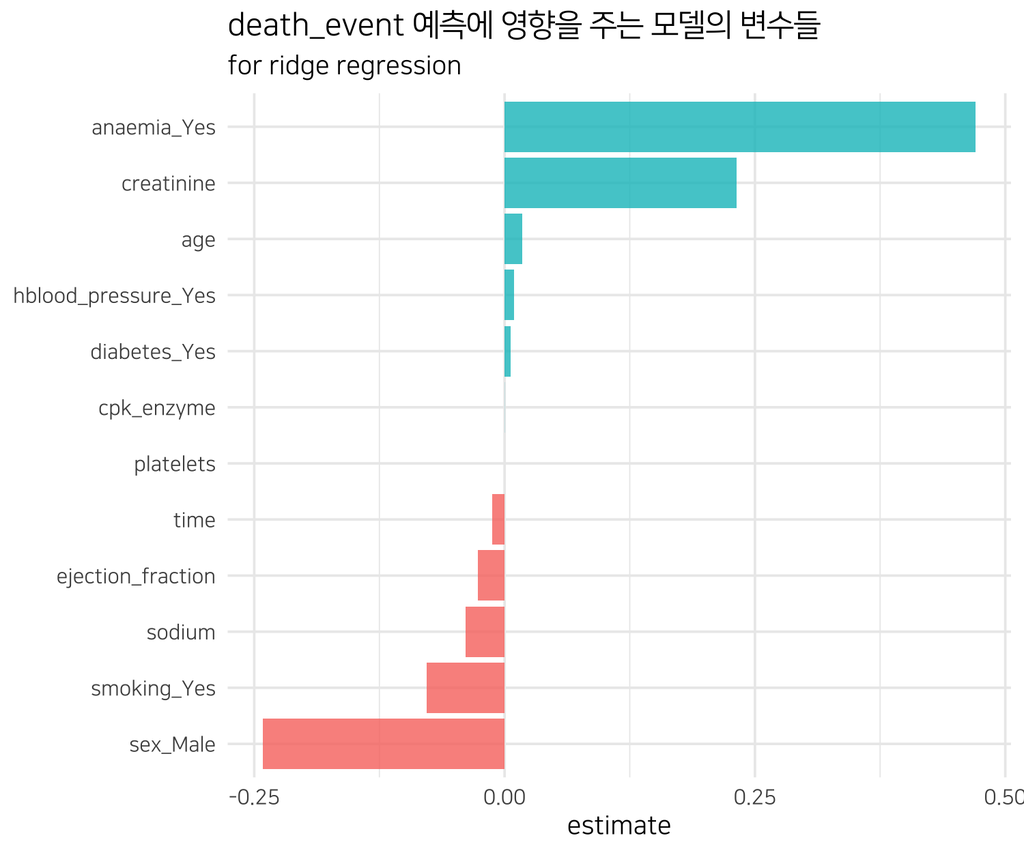

```r
viz_model(my_model, "coef")
```

#### Confusion Matrix 구하기

Confusion Matrix도 `info_model()` 함수로 구합니다.

```r
info_model(my_model, "cmat")
          Truth
Prediction No Yes
       No  48   8
       Yes 13  21
```

Confusion Matrix도 시각화할 수 있습니다. 물론 `viz_model()` 함수를 사용합니다.

Confusion Matrix 결과를 heatmap 플롯으로 시각화하기 위해서는 “heatmap” 인수를 사용합니다.

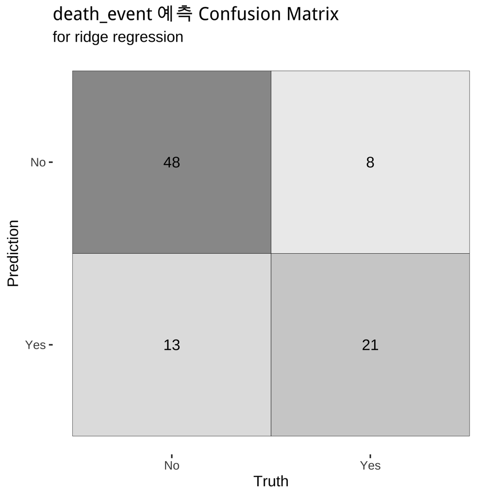

```r
viz_model(my_model, "heatmap")
```

Confusion Matrix 결과를 mosaic 플롯으로 시각화하기 위해서는 “mosaic” 인수를 사용합니다.

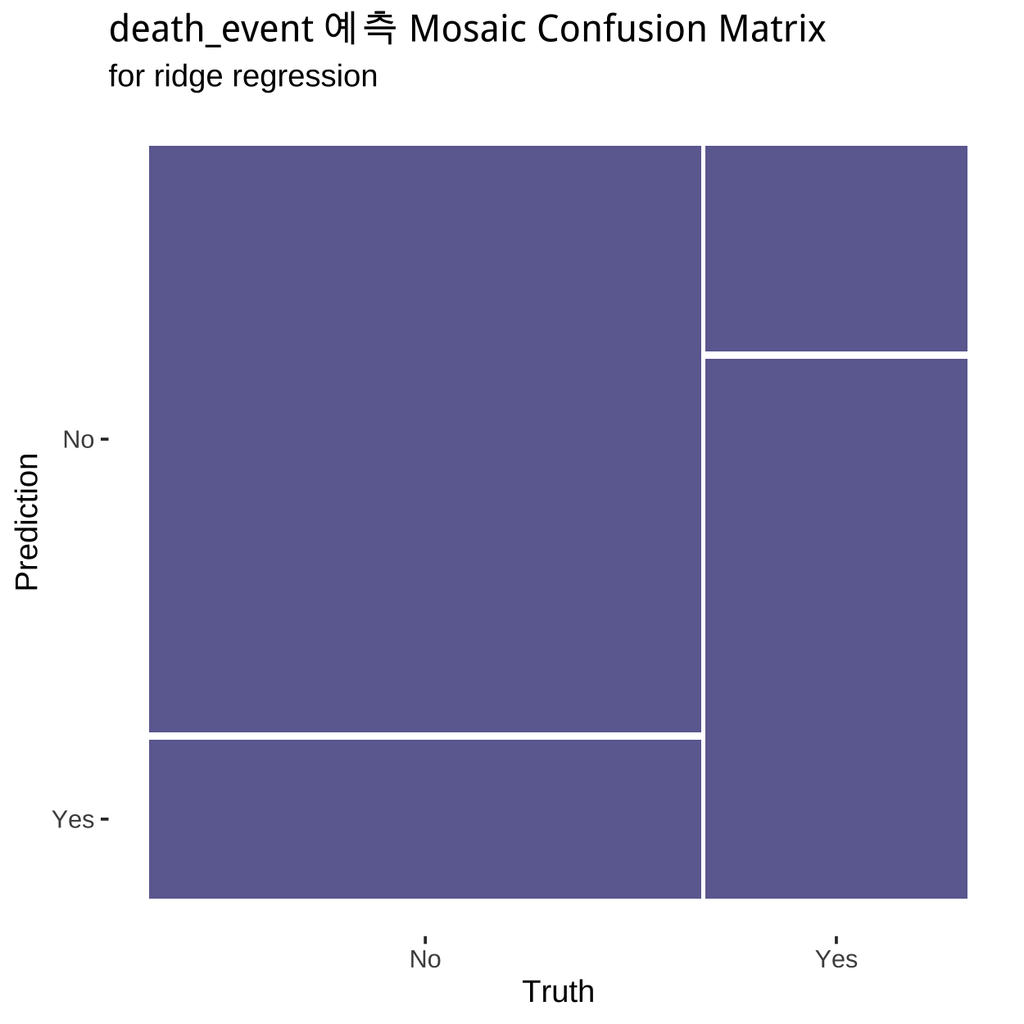

```r
viz_model(my_model, "mosaic")
```

#### 성능 평가지표 계산하기

```r
info_model(my_model, "metrics") %>%
  print(n = 20)
# A tibble: 17 × 3
   .metric              .estimator .estimate
   <chr>                <chr>          <dbl>
 1 accuracy             binary         0.767
 2 bal_accuracy         binary         0.756
 3 detection_prevalence binary         0.622
 4 f_meas               binary         0.821
 5 f_meas_05            binary         0.842
 6 f_meas_2             binary         0.8
 7 j_index              binary         0.511
 8 kap                  binary         0.489
 9 mcc                  binary         0.493
10 npv                  binary         0.618
11 ppv                  binary         0.857
12 precision            binary         0.857
13 recall               binary         0.787
14 sensitivity          binary         0.787
15 specificity          binary         0.724
16 gmean                binary         0.755
17 roc_auc              binary         0.856
```

그리고 `viz_model()` 함수로는 ROC 커브를 그릴 수 있습니다.

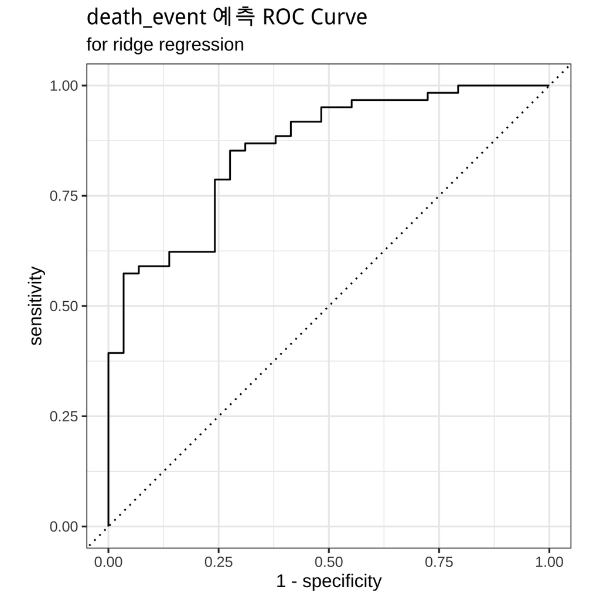

```r
viz_model(my_model, "roc")
```

“density” 인수를 적용하면 예측 확률의 구간별 target 클래스별 분포를 시각화할 수도 있습니다.

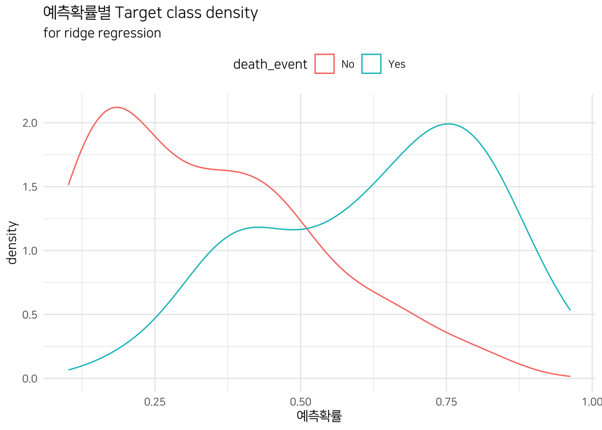

```r
viz_model(my_model, "density")
```

#### 확률 구간별 positive 예측 확률 구하기

target 변수의 positive 예측 확률을 quantiles 구간으로 비닝한 후 개별 빈의 분포를 살표볼 수 있습니다.

`info_model()` 함수의 인수에 단지 “quantiles”만 기술하면 됩니다.

```r
info_model(my_model, "quantiles")
```

```
# A tibble: 10 × 6
   binn              n positive negative prob_positive  lift
   <chr>         <int>    <int>    <int>         <dbl> <dbl>
 1 (0,0.123]         9        0        9         0     0
 2 (0.123,0.192]     9        0        9         0     0
 3 (0.192,0.232]     9        1        8         0.111 0.345
 4 (0.232,0.342]     9        0        9         0     0
 5 (0.342,0.4]       9        6        3         0.667 2.07
 6 (0.4,0.462]       9        0        9         0     0
 7 (0.462,0.562]     9        3        6         0.333 1.03
 8 (0.562,0.669]     9        4        5         0.444 1.38
 9 (0.669,0.785]     9        7        2         0.778 2.41
10 (0.785,0.962]     9        8        1         0.889 2.76
```

`nbins` 인수를 사용하면 빈의 개수를 지정할 수도 있습니다.

```r
info_model(my_model, "quantiles", nbins = 7)
```

```
# A tibble: 7 × 6
  binn              n positive negative prob_positive  lift
  <chr>         <int>    <int>    <int>         <dbl> <dbl>
1 (0,0.164]        12        0       12        0      0
2 (0.164,0.225]    13        1       12        0.0769 0.239
3 (0.225,0.375]    13        1       12        0.0769 0.239
4 (0.375,0.449]    13        5        8        0.385  1.19
# … with 3 more rows
```

좀더 쉽게 파악하고 싶다구요? 시각화를 해 보세요!

`viz_model()` 함수의 인수에 단지 “bin”만 기술하면 됩니다.

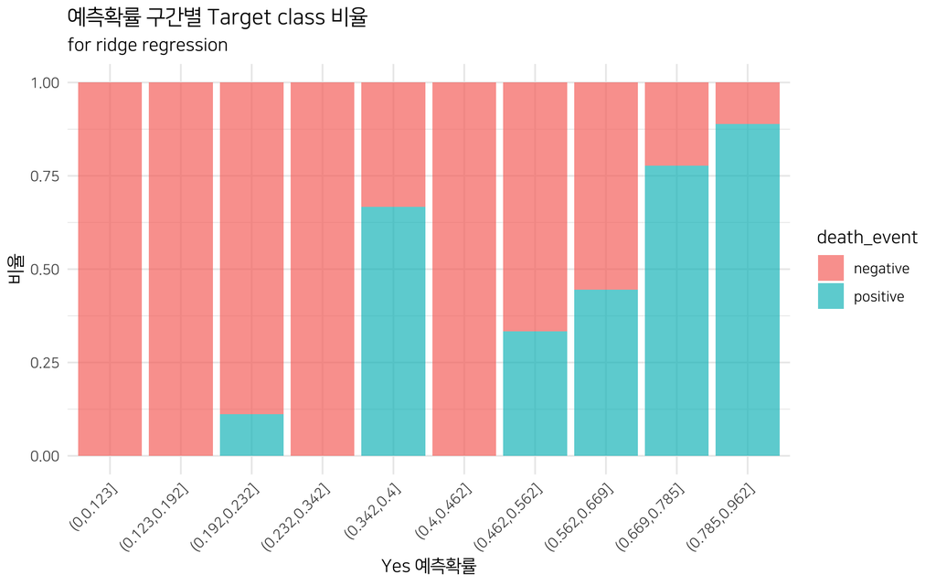

```r
viz_model(my_model, "bin")
```

`nbins` 인수를 사용하면 빈의 개수를 지정할 수도 있습니다.

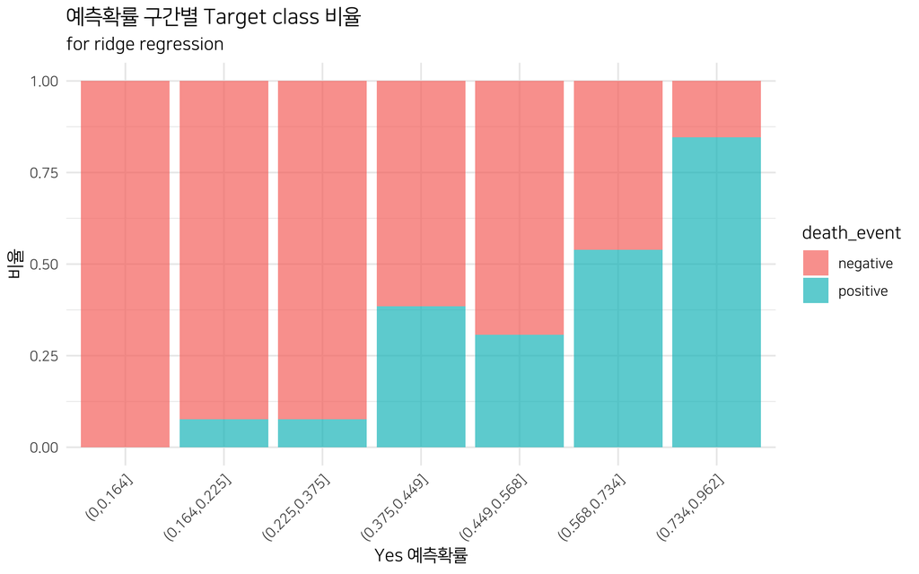

```r
viz_model(my_model, "bin", nbins = 7)
```

## 여러 binary classifiers를 적용한 모델링

bitmodeling에서 제공하는 binary classifiers 여러 개를 한번에 적합할 수 있습니다.

### 복수 binary classifiers 적합하기

`multi_classifiers()` 함수가 여러 개의 binary classifiers 여러개를 한번에 적합하도록 도와줍니다. 사용 방법은 `get_training()` 함수와 유사합니다.

여기서는 Ridge Regression과 Random Forest classifiers를 적합합니다. 만약에 classifiers 6종 모두 적합하려면 `classifiers` 인수를 지정하지 않으면 됩니다.

```r
my_models <- multi_classifiers(data_recipe, classifiers = c("ridge", "ranger"))

── Start ridge modeling ────────────────────────────────────────────────────────
ℹ Step 1 : cross validation and hyper parameters
✔ Step 1 : cross validation and hyper parameters [2.5s]

ℹ Step 2 : choice best model and fit final model with train set
✔ Step 2 : choice best model and fit final model with train set [160ms]

ℹ Step 3 : predict with test set
✔ Step 3 : predict with test set [223ms]

ℹ Step 4 : solve the evaluate metrics
✔ Step 4 : solve the evaluate metrics [26ms]

── Start ranger modeling ───────────────────────────────────────────────────────
ℹ Step 1 : cross validation and hyper parameters
✔ Step 1 : cross validation and hyper parameters [47.8s]

ℹ Step 2 : choice best model and fit final model with train set
✔ Step 2 : choice best model and fit final model with train set [166ms]

ℹ Step 3 : predict with test set
✔ Step 3 : predict with test set [239ms]

ℹ Step 4 : solve the evaluate metrics
✔ Step 4 : solve the evaluate metrics [30ms]
```

### 모델의 성능 평가

#### 통계량 보기

`compare_info_model()` 함수로 성능평가를 위한 정보를 추출할 수 있습니다. `info_model()`과 사용법이 거의 유사하므로 여기서는 간단하게 성능지표만 추출해 봅니다.

```r
compare_info_model(my_models, "metrics")
$ridge
# A tibble: 17 × 3
  .metric              .estimator .estimate
  <chr>                <chr>          <dbl>
1 accuracy             binary         0.778
2 bal_accuracy         binary         0.764
3 detection_prevalence binary         0.633
4 f_meas               binary         0.831
# … with 13 more rows

$ranger
# A tibble: 17 × 3
  .metric              .estimator .estimate
  <chr>                <chr>          <dbl>
1 accuracy             binary         0.856
2 bal_accuracy         binary         0.830
3 detection_prevalence binary         0.689
4 f_meas               binary         0.894
# … with 13 more rows
```

`merge` 인수를 TRUE로 지정하면, 복수개의 모델을 하나의 데이터로 병합해 줍니다.

```r
compare_info_model(my_models, "metrics", merge = TRUE)
# A tibble: 34 × 4
  classifier .metric              .estimator .estimate
  <chr>      <chr>                <chr>          <dbl>
1 ridge      accuracy             binary         0.778
2 ridge      bal_accuracy         binary         0.764
3 ridge      detection_prevalence binary         0.633
4 ridge      f_meas               binary         0.831
# … with 30 more rows
```

각 성능 지표별로 어떤 classifiers가 우수한가를 보기위해서는 다음처럼 dplyr 구분을 사용하면 유용합니다.

```r
compare_info_model(my_models, "metrics", merge = TRUE) %>%
  arrange(.metric, desc(.estimate)) %>%
  print(n = Inf)
# A tibble: 34 × 4
   classifier .metric              .estimator .estimate
   <chr>      <chr>                <chr>          <dbl>
 1 ranger     accuracy             binary         0.856
 2 ridge      accuracy             binary         0.778
 3 ranger     bal_accuracy         binary         0.830
 4 ridge      bal_accuracy         binary         0.764
 5 ranger     detection_prevalence binary         0.689
 6 ridge      detection_prevalence binary         0.633
 7 ranger     f_meas               binary         0.894
 8 ridge      f_meas               binary         0.831
 9 ranger     f_meas_05            binary         0.890
10 ridge      f_meas_05            binary         0.848
11 ranger     f_meas_2             binary         0.899
12 ridge      f_meas_2             binary         0.814
13 ranger     gmean                binary         0.827
14 ridge      gmean                binary         0.763
15 ranger     j_index              binary         0.660
16 ridge      j_index              binary         0.527
17 ranger     kap                  binary         0.666
18 ridge      kap                  binary         0.509
19 ranger     mcc                  binary         0.667
20 ridge      mcc                  binary         0.511
21 ranger     npv                  binary         0.786
22 ridge      npv                  binary         0.636
23 ranger     ppv                  binary         0.887
24 ridge      ppv                  binary         0.860
25 ranger     precision            binary         0.887
26 ridge      precision            binary         0.860
27 ranger     recall               binary         0.902
28 ridge      recall               binary         0.803
29 ranger     roc_auc              binary         0.925
30 ridge      roc_auc              binary         0.854
31 ranger     sensitivity          binary         0.902
32 ridge      sensitivity          binary         0.803
33 ranger     specificity          binary         0.759
34 ridge      specificity          binary         0.724
```

#### 시각화 하기

`compare_viz_model()` 함수로 성능평가를 위한 정보를 추출할 수 있습니다. `viz_model()`과 사용법이 거의 유사하므로 여기서는 간단하게 예측 확률의 구간별 target 클래스별 분포 시각화만 수행해 봅니다.

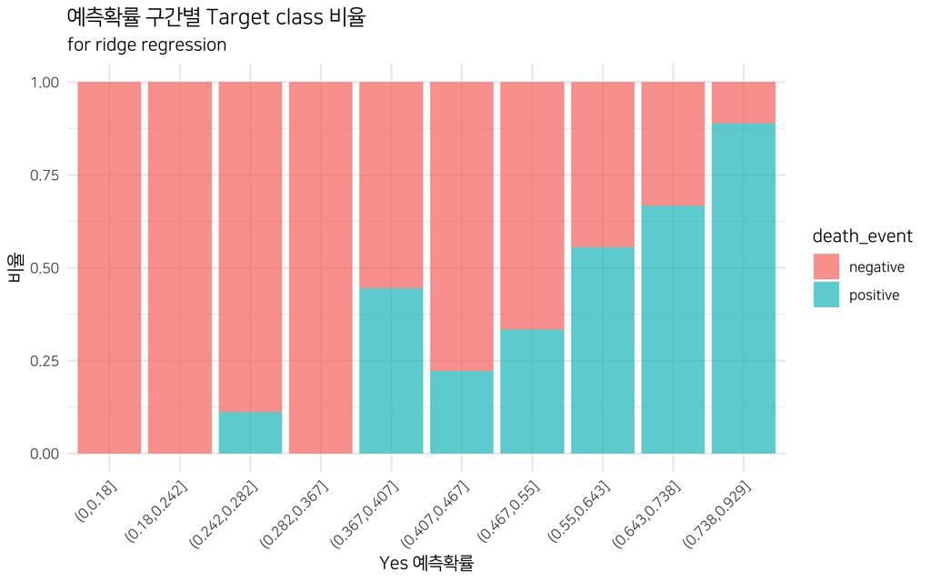

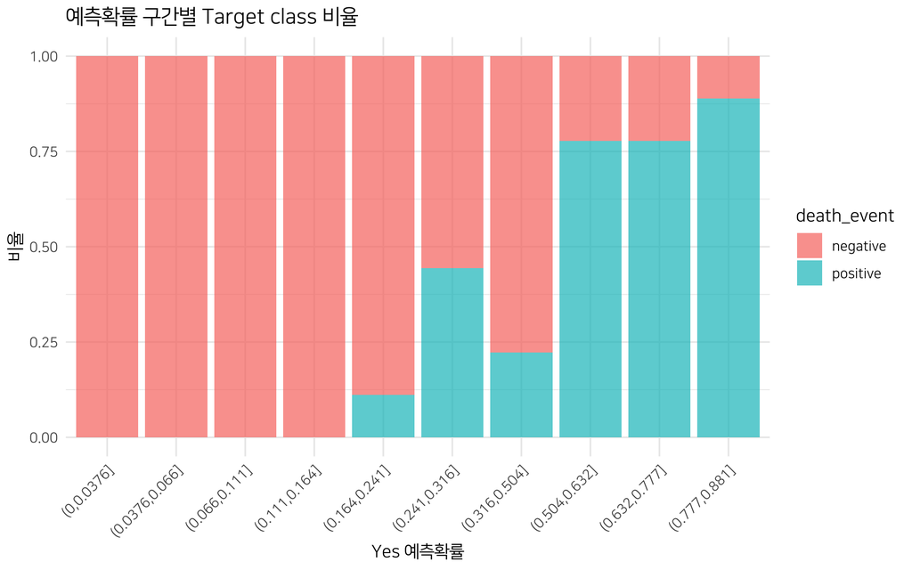

```r
compare_viz_model(my_models, "bin")
```

## 복수개의 레시피에 여러 binary classifiers 적용하기

여러 레시피를 한번에 적합할 필요가 있을 수 있습니다. `multi_recipes()` 함수가 이를 지원합니다.

### 복수 레시피 적합하기

다음은 두개 레시피에 대해서 Ridge Regression과 Random Forest classifiers 모델을 적합합니다.

- 첫번 째 레시피
  - death_event ~ .
- 두번 째 레시피
  - diabetes ~ .

```r
# 모델 개발을 위한 첫째 recipe 정의
death_event_recipe <- dlookr::heartfailure %>%
  target_to(death_event) %>%
  set_positive("Yes") %>%
  split_dataset(prop = 0.7) %>%
  extract_dataset() %>%
  set_formula() %>%
  step_my_center() %>%
  step_my_dummy() %>%
  step_my_rose()

# 모델 개발을 위한 둘째 recipe 정의
diabetes_recipe <- dlookr::heartfailure %>%
  target_to(diabetes) %>%
  set_positive("Yes") %>%
  split_dataset(prop = 0.7) %>%
  extract_dataset() %>%
  set_formula() %>%
  step_my_center() %>%
  step_my_dummy() %>%
  step_my_rose()

# recipe를 성분으로 갖는 list 정의
recipes <- list(death_event_recipe, diabetes_recipe)

my_recipes <- multi_recipes(recipes, classifiers = c("ridge", "ranger"))
══ Start formula modeling [1/2] ═════════════════════════════ death_event ~ . ══

── Start ridge modeling ────────────────────────────────────────────────────────
ℹ Step 1 : cross validation and hyper parameters
✔ Step 1 : cross validation and hyper parameters [2.5s]

ℹ Step 2 : choice best model and fit final model with train set
✔ Step 2 : choice best model and fit final model with train set [160ms]

ℹ Step 3 : predict with test set
✔ Step 3 : predict with test set [221ms]

ℹ Step 4 : solve the evaluate metrics
✔ Step 4 : solve the evaluate metrics [30ms]

── Start ranger modeling ───────────────────────────────────────────────────────
ℹ Step 1 : cross validation and hyper parameters
✔ Step 1 : cross validation and hyper parameters [48.5s]

ℹ Step 2 : choice best model and fit final model with train set
✔ Step 2 : choice best model and fit final model with train set [166ms]

ℹ Step 3 : predict with test set
✔ Step 3 : predict with test set [241ms]

ℹ Step 4 : solve the evaluate metrics
✔ Step 4 : solve the evaluate metrics [30ms]

══ Start formula modeling [2/2] ════════════════════════════════ diabetes ~ . ══

── Start ridge modeling ────────────────────────────────────────────────────────
ℹ Step 1 : cross validation and hyper parameters
✔ Step 1 : cross validation and hyper parameters [2.5s]

ℹ Step 2 : choice best model and fit final model with train set
✔ Step 2 : choice best model and fit final model with train set [160ms]

ℹ Step 3 : predict with test set
✔ Step 3 : predict with test set [225ms]

ℹ Step 4 : solve the evaluate metrics
✔ Step 4 : solve the evaluate metrics [26ms]

── Start ranger modeling ───────────────────────────────────────────────────────
ℹ Step 1 : cross validation and hyper parameters
✔ Step 1 : cross validation and hyper parameters [46.6s]

ℹ Step 2 : choice best model and fit final model with train set
✔ Step 2 : choice best model and fit final model with train set [146ms]

ℹ Step 3 : predict with test set
✔ Step 3 : predict with test set [218ms]

ℹ Step 4 : solve the evaluate metrics
✔ Step 4 : solve the evaluate metrics [30ms]
```

#### 통계량 보기

`compare_info_model()` 함수로 성능평가를 위한 정보를 추출할 수 있습니다. `info_model()`과 사용법이 거의 유사하므로 여기서는 간단하게 성능지표만 추출해 봅니다.

다만 복수개의 레시피 모델의 결과는 레시피 결과를 성분으로 갖는 리스트 객체로 반환되므로 다음처럼 “[[” 연산자로 레시피 내에서의 classifiers 별로 성능을 비교합니다. 이 예제는 첫째 레시피인 `death_event ~ .` 포뮬러에 대한 통계량입니다.

```r
compare_info_model(my_recipes[[1]], "metrics")
$ridge
# A tibble: 17 × 3
  .metric              .estimator .estimate
  <chr>                <chr>          <dbl>
1 accuracy             binary         0.767
2 bal_accuracy         binary         0.765
3 detection_prevalence binary         0.6
4 f_meas               binary         0.817
# … with 13 more rows

$ranger
# A tibble: 17 × 3
  .metric              .estimator .estimate
  <chr>                <chr>          <dbl>
1 accuracy             binary         0.8
2 bal_accuracy         binary         0.771
3 detection_prevalence binary         0.678
4 f_meas               binary         0.852
# … with 13 more rows
```

#### 시각화 하기

`compare_viz_model()` 함수로 성능평가를 위한 정보를 추출할 수 있습니다. `viz_model()`과 사용법이 거의 유사하므로 여기서는 간단하게 예측 확률의 구간별 target 클래스별 분포 시각화만 수행해 봅니다.

역시 “[[” 연산자로 레시피 내에서의 classifiers 별로 시각화합니다. 이 예제는 첫째 레시피인 `death_event ~ .` 포뮬러에 대한 시각화입니다.

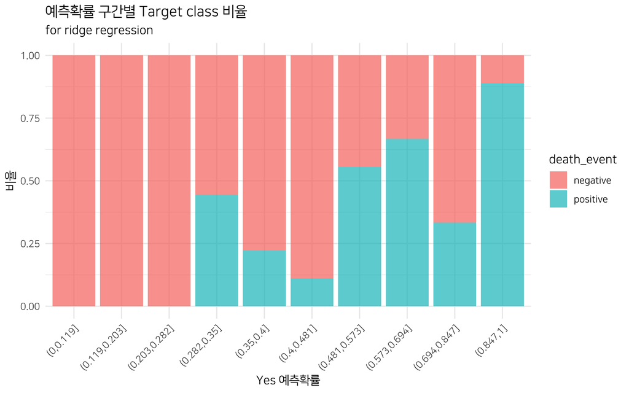

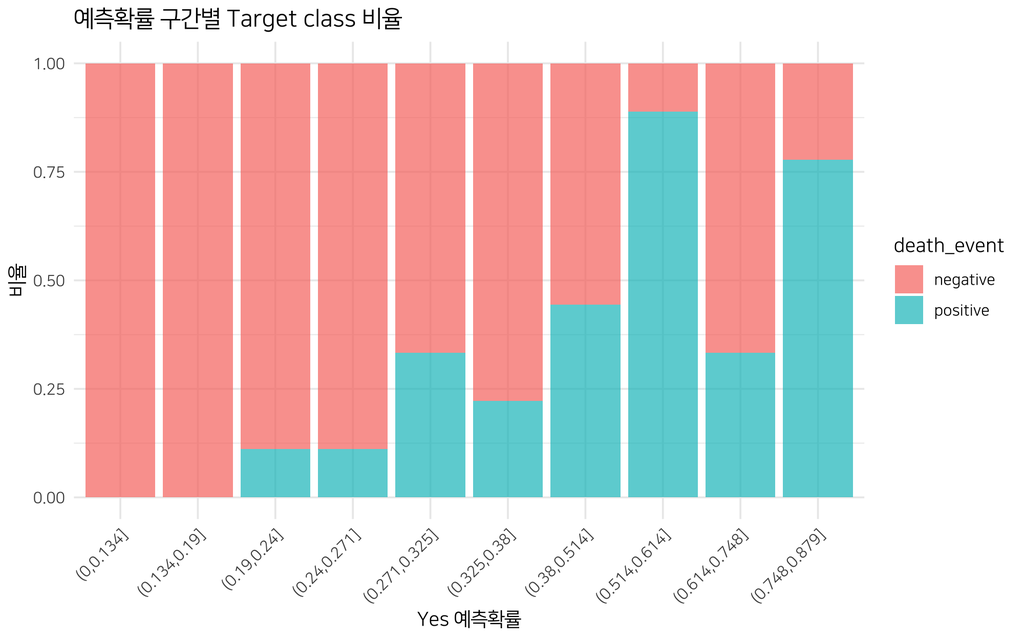

```r
compare_viz_model(my_recipes[[1]], "bin")
```

## 모델의 성능평가 보고서 작성

bitmodeling 패키지는 모델의 성능평가 보고서를 자동으로 생성해 줍니다.

모델의 성능 평가 보고서는 다음과 같은 유형으로 생성해 줍니다.

- 단일 classifier 모델 리포트
- 다중 classifiers 모델 비교 리포트
- recipe별 모델 비교 리포트
  - recipe별로 classifiers 모델 비교 리포트 생성

### 단일 classifier 모델 리포트

단일 classifier 모델에 대한 성능평가 보고서는 `report_model()`을 이용해서 생성합니다.

```r
# 모델 개발을 위한 recipe 정의
data_recipe <- dlookr::heartfailure %>%
  target_to(death_event) %>%
  set_positive("Yes") %>%
  split_dataset(prop = 0.7) %>%
  extract_dataset() %>%
  set_formula() %>%
  step_my_center() %>%
  step_my_dummy() %>%
  step_my_rose()

# logistic regrssion 적합
my_model <- get_training(data_recipe)

# logistic regrssion 성능평가 보고서 출력
report_model(my_model)
```

### 다중 classifiers 모델 비교 리포트

다중 classifier 모델에 대한 성능평가 보고서도 `report_model()`을 이용해서 생성합니다.

```r
# 복수개의 classifiers별로 적합
# "logistic", "lasso", "elastic", "ridge", "ranger", "xgboost" classifiers를 순차 모델링
my_models <- multi_classifiers(data_recipe)

# classifiers별로 성능을 비교할 수 있는 성능평가 보고서 출력
report_model(my_models, output_file = "compare_model_performance.xlsx")
```

### recipe별 모델 비교 리포트

다중 recipe별 모델에 대한 성능평가 보고서는 `report_model_recipes()`를 이용해서 생성합니다.

다음 예제는 두 개의 recipe에 대한 성능비교를 위한 두 개의 파일을 생성합니다.

```r
# 모델 개발을 위한 첫째 recipe 정의
death_event_recipe <- dlookr::heartfailure %>%
  target_to(death_event) %>%
  set_positive("Yes") %>%
  split_dataset(prop = 0.7) %>%
  extract_dataset() %>%
  set_formula() %>%
  step_my_center() %>%
  step_my_dummy() %>%
  step_my_rose()

# 모델 개발을 위한 둘째 recipe 정의
diabetes_recipe <- dlookr::heartfailure %>%
  target_to(diabetes) %>%
  set_positive("Yes") %>%
  split_dataset(prop = 0.7) %>%
  extract_dataset() %>%
  set_formula() %>%
  step_my_center() %>%
  step_my_dummy() %>%
  step_my_rose()

# recipe를 성분으로 갖는 list 정의
recipes <- list(death_event_recipe, diabetes_recipe)

my_recipes <- multi_recipes(recipes)

# recipes별로 classifiers의 성능을 비교할 수 있는 성능평가 보고서 출력
report_model_recipes(my_recipes)

# 생성된 파일의 이름들
list.files(path = getwd(), pattern = "model_performance")
```